# reading_files

## Reading many files with a couple lines of code

Sometimes you recieve files little by little or after each season, and they are saved like “2006_water_data_fall.csv”, and then you have 40 similarly named files. What do you do? The main hero in this story is list.files()

```r
library(tidyverse)
movie_files <- list.files("X:/Agency_Files/Outcomes/Risk_Eval_Air_Mod/_Air_Risk_Evaluation/R/R_Camp/TidyTuesday/reading_files/movie_files")

movie_files
```

```
##  [1] "2006.csv"                  "2007.csv"
##  [3] "2008.csv"                  "2009.csv"
##  [5] "2010.csv"                  "2011.csv"
##  [7] "2012.csv"                  "2013.csv"
##  [9] "2014.csv"                  "2015.csv"
## [11] "2016.csv"                  "other_unrelated_data.xlsx"
```

So, we have some files that we don’t want to read. This happens a lot, especially if you haven’t yet turned off the save history tool in R Studio.But list.files() returns a character list.So we can just remove stuff using character functions.

```r
movie_files <- movie_files[grepl(".csv", movie_files)]

movie_files
```

```
##  [1] "2006.csv" "2007.csv" "2008.csv" "2009.csv" "2010.csv" "2011.csv"
##  [7] "2012.csv" "2013.csv" "2014.csv" "2015.csv" "2016.csv"
```

The OLD WAY I USED TO DO THIS was using a for loop. Before everyone starts screaming, NOOOO, I am only showing you two ways of doing this and then I will prove one point of why this isn’t the best way.

```r
movies_all <- data.frame()

for(i in movie_files){

  setwd("X:/Agency_Files/Outcomes/Risk_Eval_Air_Mod/_Air_Risk_Evaluation/R/R_Camp/TidyTuesday/reading_files/movie_files/")

  movies <- read_csv(i)

  movies_fil <- movies %>%
    filter(`Runtime (Minutes)` <= 120)

  movies_all <- rbind(movies_fil, movies_all)

}
write_csv(movies_all, "X:/Agency_Files/Outcomes/Risk_Eval_Air_Mod/_Air_Risk_Evaluation/R/R_Camp/TidyTuesday/reading_files/our_movie_list.csv")
```

These files are small. Usually I have big giant MNRISKS files. SO, it is long overdue for me to learn some apply functions.

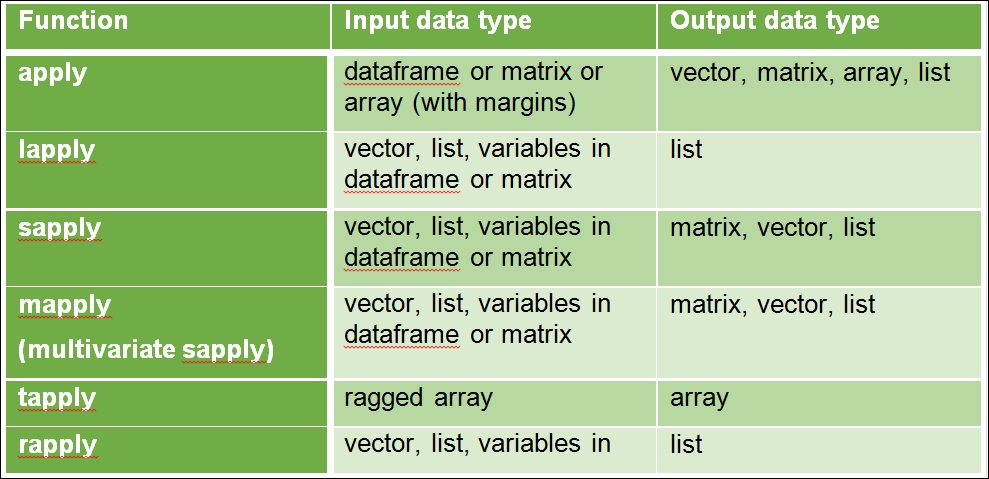

We will use lapply to read in these files and summarize them faster and more efficiently.

```r
movie_files <- list.files("X:/Agency_Files/Outcomes/Risk_Eval_Air_Mod/_Air_Risk_Evaluation/R/R_Camp/TidyTuesday/reading_files/movie_files")

movie_files <- movie_files[grepl(".csv", movie_files)]

setwd("X:/Agency_Files/Outcomes/Risk_Eval_Air_Mod/_Air_Risk_Evaluation/R/R_Camp/TidyTuesday/reading_files/movie_files")

movie_files <- movie_files %>%
  lapply(read_csv) %>%
  bind_rows() %>%
  filter(`Runtime (Minutes)` <= 120) %>%
  write_csv("X:/Agency_Files/Outcomes/Risk_Eval_Air_Mod/_Air_Risk_Evaluation/R/R_Camp/TidyTuesday/reading_files/our_movie_list_BETTER.csv")
```

But the big question is, was Derek right? Was this faster? Let’s install the package profvis to find out.

```r
##install.packages("profvis")
library(profvis)
```

To make profvis do its magic we wrap our code into curly brackets inside the profvis function. It looks like this: profvis({what you want profvis to monitor})

```r
profvis({movie_files <- list.files("X:/Agency_Files/Outcomes/Risk_Eval_Air_Mod/_Air_Risk_Evaluation/R/R_Camp/TidyTuesday/reading_files/movie_files")

movie_files <- movie_files[grepl(".csv", movie_files)]

movies_all <- data.frame()

for(i in movie_files){

  setwd("X:/Agency_Files/Outcomes/Risk_Eval_Air_Mod/_Air_Risk_Evaluation/R/R_Camp/TidyTuesday/reading_files/movie_files")

  movies <- read_csv(i)

  movies_fil <- movies %>%
    filter(`Runtime (Minutes)` <= 120)

  movies_all <- rbind(movies_fil, movies_all)

}
write_csv(movies_all, "X:/Agency_Files/Outcomes/Risk_Eval_Air_Mod/_Air_Risk_Evaluation/R/R_Camp/TidyTuesday/reading_files/our_movie_list.csv")

})
```

[interactive chart not shown]

So, that was 200 ms or so. Let’s see how the lapply version works.

```r
profvis({movie_files <- list.files("X:/Agency_Files/Outcomes/Risk_Eval_Air_Mod/_Air_Risk_Evaluation/R/R_Camp/TidyTuesday/reading_files/movie_files")

movie_files <- movie_files[grepl(".csv", movie_files)]

setwd("X:/Agency_Files/Outcomes/Risk_Eval_Air_Mod/_Air_Risk_Evaluation/R/R_Camp/TidyTuesday/reading_files/movie_files")

movie_files <- movie_files %>%
  lapply(read_csv) %>%
  bind_rows() %>%
  filter(`Runtime (Minutes)` <= 120) %>%
  write_csv("X:/Agency_Files/Outcomes/Risk_Eval_Air_Mod/_Air_Risk_Evaluation/R/R_Camp/TidyTuesday/reading_files/our_movie_list_BETTER.csv")
})
```

[interactive chart not shown]

The lapply version is faster (180 ms). Derek is right! Derek is always right. Listen to Derek.

But, in all honesty the movie data didn’t come to me in year based files. I lied. I had to write a for loop to save these files, because I hadn’t yet forced myself to learn lapply as of 2pm yesterday afternoon. So, let’s see how I did this in reverse. I will read in a file, and save it in pieces based on a category in the data. Then, I will pose a question.

```r
##make the data

movies <- read_csv("X:/Agency_Files/Outcomes/Risk_Eval_Air_Mod/_Air_Risk_Evaluation/R/R_Camp/TidyTuesday/reading_files/movie_files")

years <- 2006:2016


setwd("X:/Agency_Files/Outcomes/Risk_Eval_Air_Mod/_Air_Risk_Evaluation/R/R_Camp/TidyTuesday/reading_files/movie_files")

for(i in years){
  movies_year <- filter(movies, Year == i)
  write_csv(movies_year, paste0("X:/Agency_Files/Outcomes/Risk_Eval_Air_Mod/_Air_Risk_Evaluation/R/R_Camp/TidyTuesday/reading_files/movie_files", i, ".csv"))
}
```

But again, I am trying to stop using for loops because I want to be faster and more efficient and not have my computer churning away day after day opening, summarizing and saving MNRISKS files.

```r
movies <- read_csv("X:/Agency_Files/Outcomes/Risk_Eval_Air_Mod/_Air_Risk_Evaluation/R/R_Camp/TidyTuesday/reading_files/movie_data.csv")
movies <- split(movies, movies$Year)

write <- function(i){write_csv(i, paste0("X:/Agency_Files/Outcomes/Risk_Eval_Air_Mod/_Air_Risk_Evaluation/R/R_Camp/TidyTuesday/reading_files/new_movie_data", i$Year[1], ".csv"))}

lapply(movies, write)
```

```
## $`2006`
## # A tibble: 44 x 12
##     Rank Title Genre Description Director Actors  Year `Runtime (Minut~ Rating
##    <dbl> <chr> <chr> <chr>       <chr>    <chr>  <dbl>            <dbl>  <dbl>
##  1    65 The ~ Dram~ Two stage ~ Christo~ Chris~  2006              130    8.5
##  2    79 Pira~ Acti~ Jack Sparr~ Gore Ve~ Johnn~  2006              151    7.3
##  3   100 The ~ Crim~ An underco~ Martin ~ Leona~  2006              151    8.5
##  4   114 300   Acti~ King Leoni~ Zack Sn~ Gerar~  2006              117    7.7
##  5   165 Casi~ Acti~ Armed with~ Martin ~ Danie~  2006              144    8
##  6   222 Cars  Anim~ A hot-shot~ John La~ Owen ~  2006              117    7.1
##  7   231 Pan'~ Dram~ In the fal~ Guiller~ Ivana~  2006              118    8.2
##  8   233 Apoc~ Acti~ As the May~ Mel Gib~ Gerar~  2006              139    7.8
##  9   247 Chil~ Dram~ In 2027, i~ Alfonso~ Julia~  2006              109    7.9
## 10   298 The ~ Come~ A smart bu~ David F~ Anne ~  2006              109    6.8
## # ... with 34 more rows, and 3 more variables: Votes <dbl>, `Revenue
## #   (Millions)` <dbl>, Metascore <dbl>
##
## $`2007`
## # A tibble: 53 x 12
##     Rank Title Genre Description Director Actors  Year `Runtime (Minut~ Rating
##    <dbl> <chr> <chr> <chr>       <chr>    <chr>  <dbl>            <dbl>  <dbl>
##  1    40 5/25~ Come~ "Alienated~ Patrick~ John ~  2007              113    7.1
##  2    76 Pira~ Acti~ "Captain B~ Gore Ve~ Johnn~  2007              169    7.1
##  3   137 No C~ Crim~ "Violence ~ Ethan C~ Tommy~  2007              122    8.1
##  4   149 Supe~ Come~ "Two co-de~ Greg Mo~ Micha~  2007              113    7.6
##  5   156 Alie~ Acti~ "Warring a~ Colin S~ Reiko~  2007               94    4.7
##  6   160 Hot ~ Acti~ "Exception~ Edgar W~ Simon~  2007              121    7.9
##  7   198 Into~ Adve~ "After gra~ Sean Pe~ Emile~  2007              148    8.1
##  8   213 Tran~ Acti~ "An ancien~ Michael~ Shia ~  2007              144    7.1
##  9   278 Zodi~ Crim~ "In the la~ David F~ Jake ~  2007              157    7.7
## 10   283 Deat~ Thri~ "Two separ~ Quentin~ Kurt ~  2007              113    7.1
## # ... with 43 more rows, and 3 more variables: Votes <dbl>, `Revenue
## #   (Millions)` <dbl>, Metascore <dbl>
##
## $`2008`
## # A tibble: 52 x 12
##     Rank Title Genre Description Director Actors  Year `Runtime (Minut~ Rating
##    <dbl> <chr> <chr> <chr>       <chr>    <chr>  <dbl>            <dbl>  <dbl>
##  1    55 The ~ Acti~ "When the ~ Christo~ Chris~  2008              152    9
##  2   129 Mamm~ Come~ "The story~ Phyllid~ Meryl~  2008              108    6.4
```

[output cut: 131 more lines]

```
## # A tibble: 297 x 12
##     Rank Title Genre Description Director Actors  Year `Runtime (Minut~ Rating
##    <dbl> <chr> <chr> <chr>       <chr>    <chr>  <dbl>            <dbl>  <dbl>
##  1     3 Split Horr~ "Three gir~ M. Nigh~ James~  2016              117    7.3
##  2     4 Sing  Anim~ "In a city~ Christo~ Matth~  2016              108    7.2
##  3     5 Suic~ Acti~ "A secret ~ David A~ Will ~  2016              123    6.2
##  4     6 The ~ Acti~ "European ~ Yimou Z~ Matt ~  2016              103    6.1
##  5     7 La L~ Come~ "A jazz pi~ Damien ~ Ryan ~  2016              128    8.3
##  6     8 Mind~ Come~ "A has-bee~ Sean Fo~ Essie~  2016               89    6.4
##  7     9 The ~ Acti~ "A true-li~ James G~ Charl~  2016              141    7.1
##  8    10 Pass~ Adve~ "A spacecr~ Morten ~ Jenni~  2016              116    7
##  9    11 Fant~ Adve~ "The adven~ David Y~ Eddie~  2016              133    7.5
## 10    12 Hidd~ Biog~ "The story~ Theodor~ Taraj~  2016              127    7.8
## # ... with 287 more rows, and 3 more variables: Votes <dbl>, `Revenue
## #   (Millions)` <dbl>, Metascore <dbl>
```

```r
profvis({movies <- read_csv("X:/Agency_Files/Outcomes/Risk_Eval_Air_Mod/_Air_Risk_Evaluation/R/R_Camp/TidyTuesday/reading_files/movie_data.csv")

years <- 2006:2016


for(i in years){
  movies_year <- filter(movies, Year == i)
  write_csv(movies_year, paste0("X:/Agency_Files/Outcomes/Risk_Eval_Air_Mod/_Air_Risk_Evaluation/R/R_Camp/TidyTuesday/reading_files/movie_files", i, ".csv"))
}})
```

[interactive chart not shown]

That took about 150ms. Let’s see how long hte lapply version takes.

```r
##Then using lapply()

profvis({movies <- read_csv("X:/Agency_Files/Outcomes/Risk_Eval_Air_Mod/_Air_Risk_Evaluation/R/R_Camp/TidyTuesday/reading_files/movie_data.csv")

movies <- split(movies, movies$Year)

write <- function(i){write_csv(i, paste0("X:/Agency_Files/Outcomes/Risk_Eval_Air_Mod/_Air_Risk_Evaluation/R/R_Camp/TidyTuesday/reading_files/new_movie_data", i$Year[1], ".csv"))}

lapply(movies, write)
})
```

[interactive chart not shown]

For a final tip, sometimes your data is stored in many folders. You you may want to search folders and only pull summarize and save files that include a folder path name with the word “air_ambient” in it. You can use list.dirs()

```r
directories <- list.dirs("X:/Agency_Files/Outcomes/Risk_Eval_Air_Mod/_Air_Risk_Evaluation/R/R_Camp/TidyTuesday/reading_files/")
```